# Project1

Jiaming Qu

9/24/2019

# Background Introduction

The data set is kindly provided by Urban Ministries of Druham, which records their assistance and help to people each year in different kinds of services, *e.g.*, food, clothing, hygiene kits and etc. In this project, we analyze how the service scale changes over time, from both general and specific aspect.

```r
library(ggplot2)
library(tidyverse)
library(wordcloud)
```

## Data Importing

First of all, we import the .tsv file for analysis.

```r
# read the file
setwd("/Users/jiamingqu/Desktop/BIOS 611/project/bios611-projects-fall-2019-arthur0804/project1/")
df <- read_delim("data/UMD_Services_Provided_20190719.tsv", delim="\t")
```

## Data Cleaning

We need to clean the data, *i.e.*, removing unimportant or meaningless fields, converting some columns to specific data types for analysis, and renaming the column names.

```r
# extract useful columns (remove column "field 1/2/3")
df <- df[,1:15]

# convert the datatype from character to date
df$Date <- as.Date(df$Date, "%m/%d/%Y")

# remove invalid rows with date in the future
df <- filter(df, df$Date <= Sys.Date())

# add a column of year from date
df$year <- as.numeric(format(df$Date,'%Y'))

# rename columns (remove the spaces in column names)
names(df) <- c('Date','ClientFileNumber', 'ClientFileMerge','BusTickets',
               'NotesofService','FoodProvidedfor', 'FoodPounds',
               'ClothingItems', 'Diapers', 'SchoolKits', 'HygieneKits',
               'Referrals', 'FinancialSupport', 'TypeofBill',
               'PayerofSupport','year')
```

## Data Analysis

In this section, we provide a detailed data analysis which starts from a general view to a specific view at some aspect.

First let’s get a summary of the data frame, this help us to have an idea of the general distribution of the data, and find potential flaws in the data.

```r
summary(df)
```

```
##       Date            ClientFileNumber ClientFileMerge   BusTickets
##  Min.   :1931-01-12   Min.   :    1    Min.   :    0   Min.   : 0.00
##  1st Qu.:2008-04-01   1st Qu.: 3199    1st Qu.:    0   1st Qu.: 0.00
##  Median :2012-06-28   Median : 6969    Median :    0   Median : 1.00
##  Mean   :2011-10-28   Mean   : 7289    Mean   : 4560   Mean   : 1.35
##  3rd Qu.:2016-01-27   3rd Qu.:11173    3rd Qu.:    0   3rd Qu.: 2.00
##  Max.   :2019-08-31   Max.   :16792    Max.   :70108   Max.   :10.00
##                                        NA's   :37      NA's   :79573
##  NotesofService     FoodProvidedfor      FoodPounds
##  Length:79831       Min.   :   0.000   Min.   :     0.0
##  Class :character   1st Qu.:   1.000   1st Qu.:     0.0
##  Mode  :character   Median :   2.000   Median :    15.0
##                     Mean   :   2.738   Mean   :    25.4
##                     3rd Qu.:   4.000   3rd Qu.:    25.0
##                     Max.   :1151.000   Max.   :450121.0
##                     NA's   :22701      NA's   :12521
##  ClothingItems        Diapers          SchoolKits     HygieneKits
##  Min.   :  0.000   Min.   :   0.00   Min.   : 0.00   Min.   :0.00
##  1st Qu.:  4.000   1st Qu.:   1.00   1st Qu.: 0.00   1st Qu.:1.00
##  Median :  7.000   Median :  12.00   Median : 0.00   Median :1.00
##  Mean   :  8.489   Mean   :  15.41   Mean   : 1.45   Mean   :0.98
##  3rd Qu.: 11.000   3rd Qu.:  12.00   3rd Qu.: 0.00   3rd Qu.:1.00
##  Max.   :247.000   Max.   :5303.00   Max.   :25.00   Max.   :8.00
##  NA's   :10933     NA's   :78796     NA's   :79649   NA's   :76643
##   Referrals         FinancialSupport   TypeofBill
##  Length:79831       Min.   :  0.000   Length:79831
##  Class :character   1st Qu.:  0.000   Class :character
##  Mode  :character   Median :  0.000   Mode  :character
##                     Mean   :  0.432
##                     3rd Qu.:  0.000
##                     Max.   :450.000
##                     NA's   :3356
##  PayerofSupport          year
##  Length:79831       Min.   :1931
##  Class :character   1st Qu.:2008
##  Mode  :character   Median :2012
##                     Mean   :2011
##                     3rd Qu.:2016
##                     Max.   :2019
##
```

### RQ1: Is assistance and clients becoming more nowsdays than before?

This gives us a general view of how our program grows by year, we expect to see both the number of assistances and clients are growing instead of decreasing.

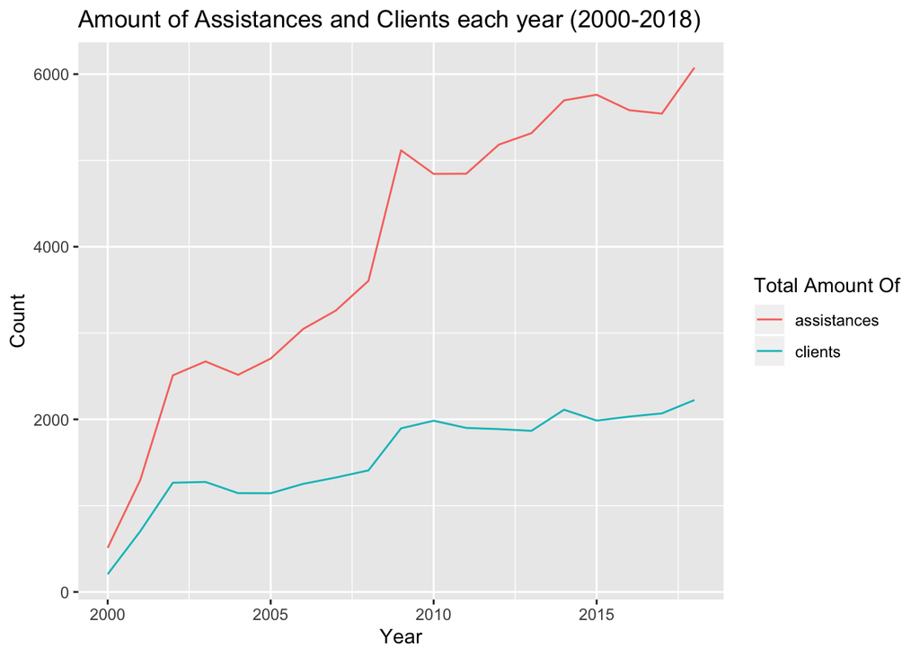

```r
# from the summary above, we can see some records are too old, we only consider 2000 to 2018
df_20years <- filter(df, df$year >= 2000 & df$year <= 2018)

# in regards of total assitances each year
df_assistance <- df_20years %>% group_by(year) %>%
    summarise(assistances = n())

# in regards of clients each year
df_client <- df_20years %>% group_by(year) %>%
    summarise(clients = length(unique(ClientFileNumber)))

# join together
df_assistance_client <- inner_join(df_assistance, df_client, by = "year")

# gather
df_assistance_client <- df_assistance_client %>% gather(type, count, c(assistances, clients))

ggplot(df_assistance_client, aes(x=year, y = count, color = type)) +
    geom_line() +
    labs(title ="Amount of Assistances and Clients each year (2000-2018)",
         x = "Year", y = "Count", color = "Total Amount Of") +
    theme_grey()
```

We can see that we are helping more and more people each year, and the total amount of recoreded assistances is also increasing.

### RQ2: How many new clients do we help each year?

Although from the analysis above we know that we are helping more and more people each year, but how many new clients are we reaching out to? By “new” clients I mean this client has never appeared before a specifc year. This helps us understand how our program grows from another prospective.

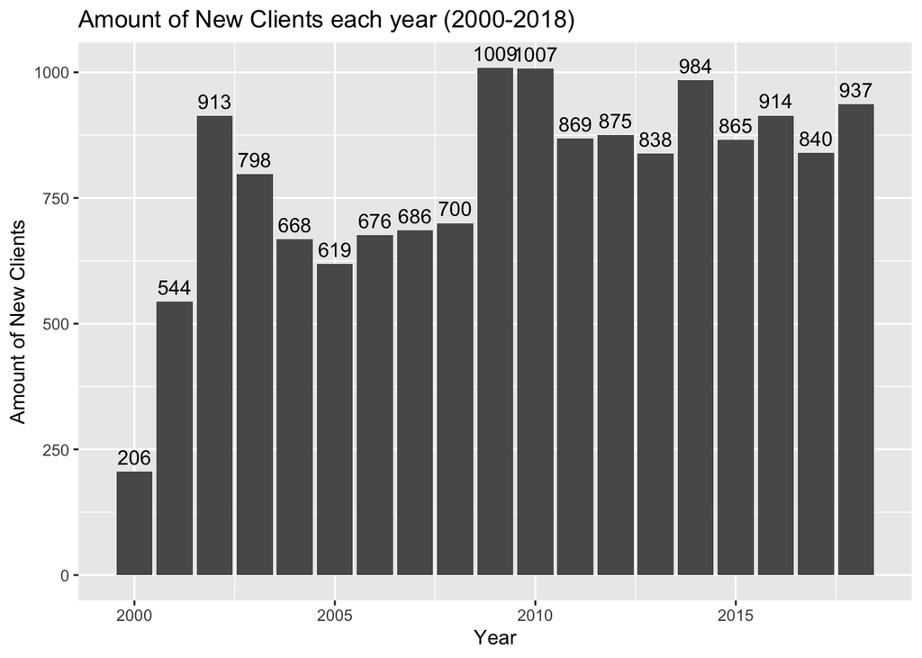

```r
# select corresponding columns
df_clients <- select(df_20years, c(2,16))

#create a data frame to store the result
df_new_clients <- data.frame(matrix(ncol = 2, nrow = 0))
x <- c("NewClients", "Year")
colnames(df_new_clients) <- x

# loop over each year
for (i in 2000:2018){

    # extract the record for this year
    df_clients_this_year <- filter(df_clients, df_clients$year == i)

    # get the unique client numbers of this year
    count_this_year <- unique(df_clients_this_year$ClientFileNumber)

    # extract the record for past years
    df_clients_past_year <- filter(df_clients, df_clients$year < i)

    # get the unique client numbers of this year
    count_past_year <- unique(df_clients_past_year$ClientFileNumber)

    # append count of new clients to the dataframe
    new_clients_count = length(setdiff(count_this_year, count_past_year))
    df_new_clients[nrow(df_new_clients) + 1,] = c(new_clients_count, i)
}

# plot
ggplot(df_new_clients, aes(x = Year, y = NewClients)) +
    geom_bar(stat = "identity") +
    geom_text(aes(label=NewClients), vjust= -0.5) +
    labs(title ="Amount of New Clients each year (2000-2018)", x = "Year",
         y = "Amount of New Clients") +
    theme_grey()
```

### RQ3: Which family/individual received the most assistance each year from 2000 to 2018?

This tells us which family received the most assistance, which should get more attention from us. Or we can follow up to see whether their conditions have become better.

```r
# create a empty data frame to store the result
df_clients_result <- data.frame(matrix(ncol = 3, nrow = 0))
x <- c("ClientFileNumber", "AssistanceReceived", "Year")
colnames(df_clients_result) <- x

# loop over each year
for (i in 2000:2018){
  # extract the record for a year
  df_clients_year <- filter(df_clients, df_clients$year == i)

  # count the amount by each unique id and then sort
  result <- arrange(df_clients_year %>% count(ClientFileNumber), desc(n))

  # add into the data frame
  df_clients_result[nrow(df_clients_result) + 1,] = c(result[1,1],result[1,2], i)
}

df_clients_result
```

```
##    ClientFileNumber AssistanceReceived Year
## 1              1027                 11 2000
## 2              1418                 12 2001
## 3               101                 12 2002
## 4              1937                 16 2003
## 5              2944                 20 2004
## 6              3502                 22 2005
## 7              1363                 15 2006
## 8               738                 16 2007
## 9              5917                 20 2008
## 10              805                 24 2009
## 11             3502                 29 2010
## 12             3502                 25 2011
## 13             3502                 36 2012
## 14             5080                 17 2013
## 15            10958                 14 2014
## 16            12670                 22 2015
## 17              193                 15 2016
## 18            13594                 20 2017
## 19            14588                 23 2018
```

### RQ4: How does each kind of services change each year?

Instead of the general amount of assistances, we also want to know how does each kind of service change, including both the count and the average amount. This helps us to understand which part has been good and which part still needs improvments. We only include the code for the first figure, for the sake of simplicity.

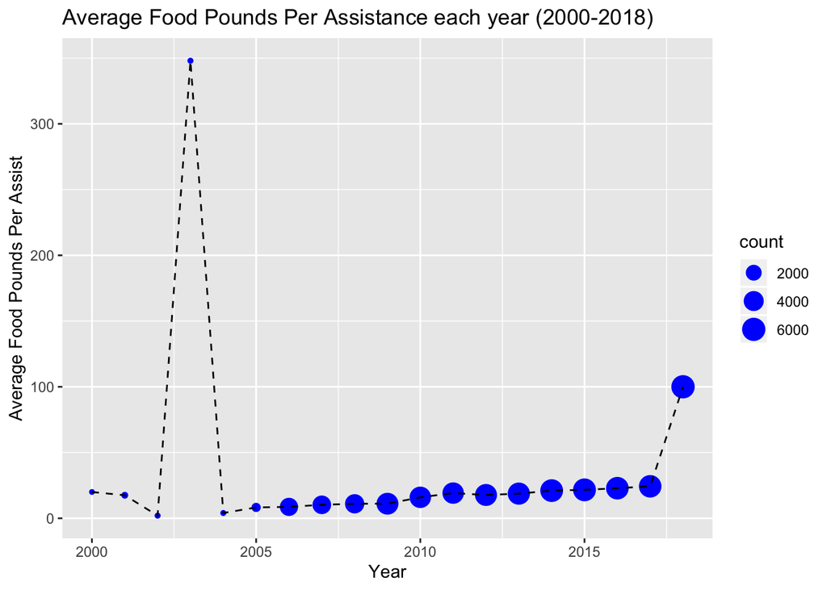

```r
# food
df_20years_food <- df_20years %>% select(FoodPounds, year)
df_20years_food <- df_20years_food %>% drop_na(FoodPounds)
food_comparision <- df_20years_food  %>% group_by(year) %>%
    summarise(avg_food = mean(FoodPounds), count = n())

ggplot(food_comparision, aes(x=year, y=avg_food)) +
    geom_point(aes(size = count), color = "blue") +
    labs(title ="Average Food Pounds Per Assistance each year (2000-2018)", x = "Year",
         y = "Average Food Pounds Per Assist") +
    geom_path(linetype = 2) +
    theme_grey()
```

From the figure above, we could see that the amount of food assistances is increasing. And apart from the ‘’outlier’’ in 2003, the average food pounds is also growing.

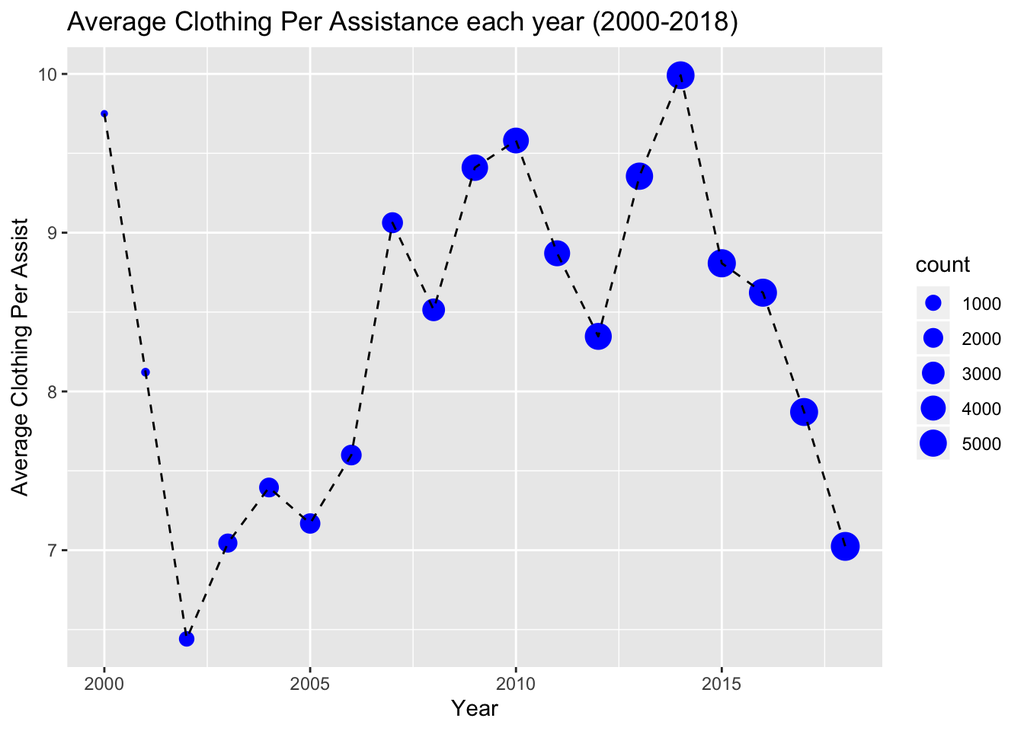

From the figure above, we could see that the amount of clothing assistances is increasing. But unfortunately, the average clothing items fluctuates over time, and is decreasing since 2014.

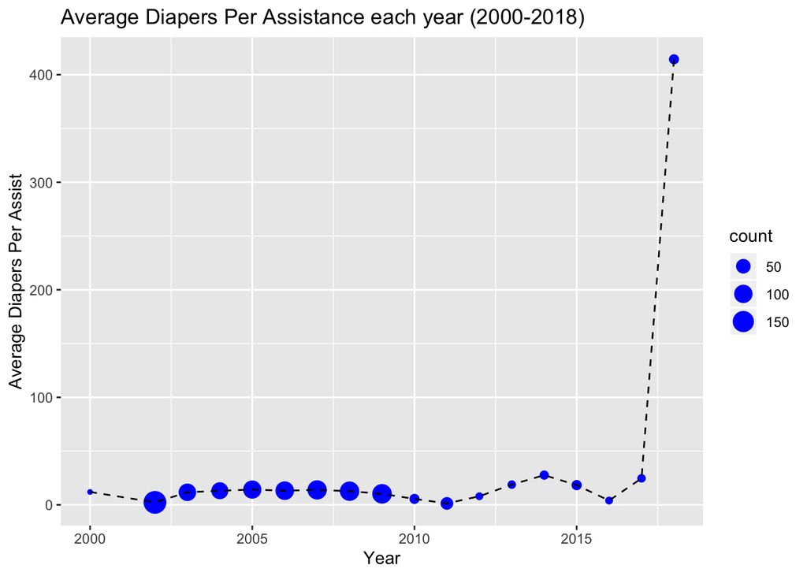

From the figure above, we could see that the amount of diapers assistances is decreasing, but the average diapers items suddenly increases to over 400 in 2018.

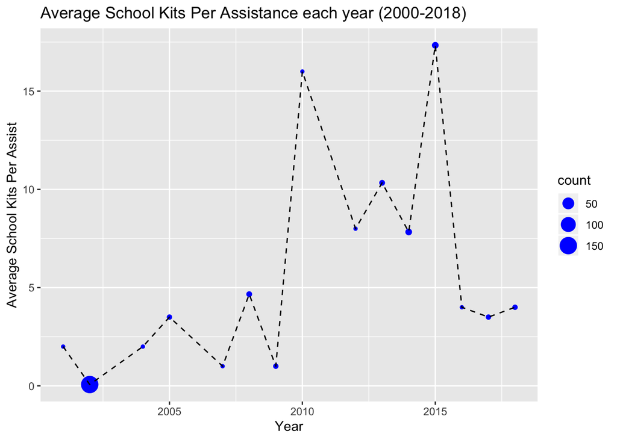

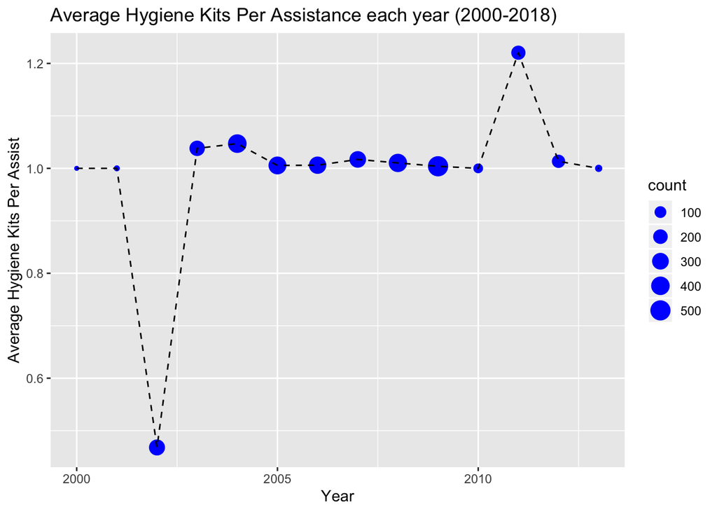

From the figure above, we could see that the amount of hygiene kits is decreasing compared to that between 2002 and 2009, and the average amount does not change a lot over these years, which keeps around 1.0.

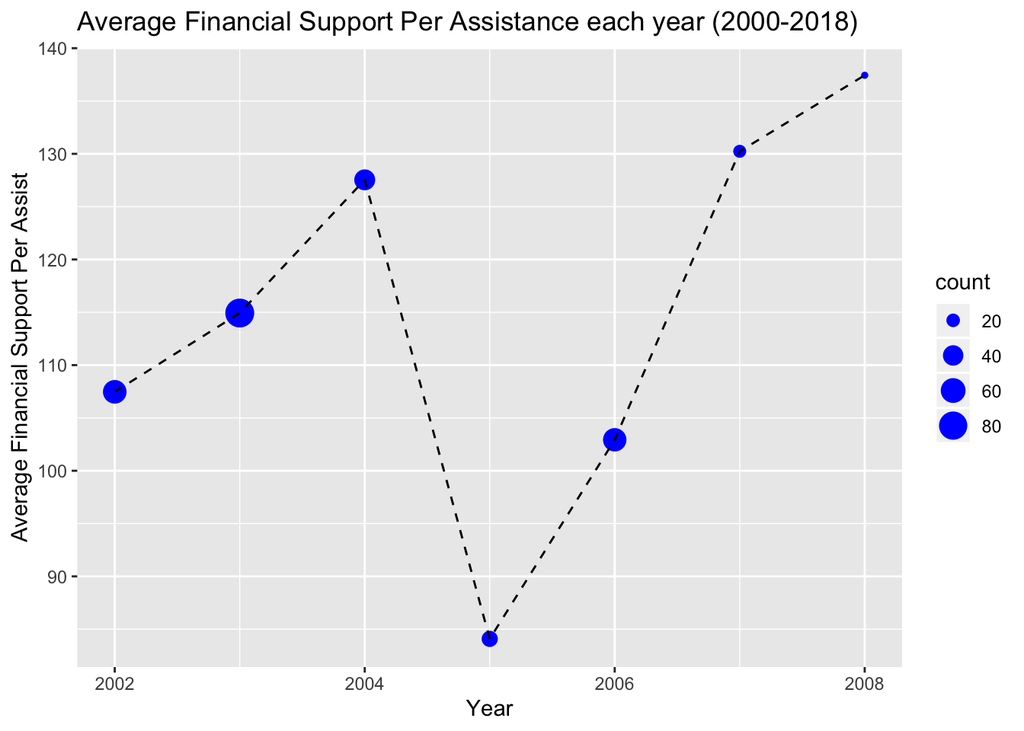

From the figure above, we could see that the average amount per financial assistance ranges from 80 to 135 these years, but the amount is decreasing. And sadly, the financial support only existed from 2002 to 2008.